# PHRM7021: Introductory Tutorial

Adam La Caze

## Agenda

1. Where to find key information
2. Course aims and objectives
3. Course design principles
4. Course components and assessment
5. Group work
6. Tips

## Contact

Adam La Caze

Post general course questions to the main PHRM7021 Discussion Board  
E: a.lacaze@uq.edu.au  
W: https://researchers.uq.edu.au/researcher/1112  
To make an appointment: calendly.com/a-lacaze

## Key information (Zoom, Blackboard, Course)

- Postgraduate Clinical Pharmacy Hub 2020: see especially `Program Information` and `Tech-related FAQs`
- [Information regarding Zoom tutorials](https://learn.uq.edu.au/bbcswebdav/xid-25029782_1)
- [2020 Teaching Dates](https://learn.uq.edu.au/bbcswebdav/xid-24969012_1)
- [PHRM7021 Course Profile](https://course-profiles.uq.edu.au/student_section_loader/section_1/106858)

## Course aims

This course is designed to provide clinical pharmacists with skills in appraising and designing research and practice improvement studies.

The course provides practical opportunities for students to develop their research skills. Students have the opportunity to conduct and analyse a small qualitative research study, develop skills in quantitative data analysis, develop research and evaluation questions, pitch project ideas and to develop a project proposal.

## Course design principles

- Tight links between learning activities, assessment and learning outcomes
- Progressively build your skills and knowledge through the semester
- Foster active collaborative learning
- Develop and demonstrate skills and knowledge that you can apply in practice

## Course objectives

1. Critically appraise and synthesise current evidence in a particular context
2. Identify a gap in practice or knowledge that can be addressed through research and evaluation
3. Develop focused, feasible, answerable research and evaluation questions
4. Demonstrate an understanding of the principles of quantitative and qualitative data analysis
5. Collect and analyse qualitative or quantitative data while ensuring the rigour and quality of that data
6. Develop a project proposal in the area of pharmacy practice covering study design, methodology, data analysis and ethical considerations
7. Communicate research ideas and project plans to a knowledgeable, non-expert audience

## Course components

- Module participation (blogs and quizzes)
- Module activities (“Green Discussion Board”)
- Tutorial activities (Blue Discussion Board)
- Peer feedback assessment
- Assignments: Project Outline, Analysis Assignment, Project Proposal

## Assessment

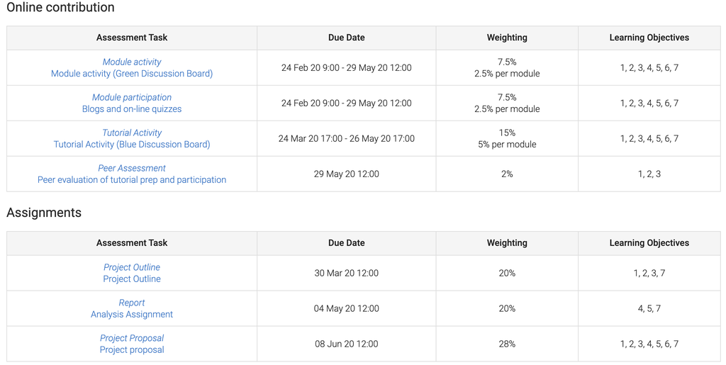

Put the long list of due dates in your diary (see [`PHRM7021Overview.pdf`](https://www.dropbox.com/s/slbl10rupub3gxu/PHRM7021Overview.pdf?dl=0) on Blackboard)

## Group Work

- Group work is an important part of PHRM7021
- [Resources](https://my.uq.edu.au/information-and-services/student-support/study-skills/group-work/forming-group) for forming and working well as a group

Spend some time *forming* the group

Agree on some general principles for the group

Recognise the variety of roles needed (and try to share these roles around throughout the course)

## Group work suggestions for PHRM7021

- *Read* the group task within the first week of the module
- *Contribute* to the group task by the second week of the module
- Contribute to each task—regardless of whether you are presenting or commenting
- Communicate to your group if your contribution is going to be delayed (or if there is a period of time you are unavailable)
- Share leadership; show leadership when you are presenting/commenting

## Tips

- [Searching for fulltext papers via Google Scholar](https://web.library.uq.edu.au/research-tools-techniques/google-scholar)
- [Digital Essentials](https://web.library.uq.edu.au/research-tools-techniques/digital-essentials)